# Object Oriented Programming in R

Statistics 506, Fall 2017

## Object Oriented Programming

When we attach values to names in an R environment we generally refer to the name and value collectively as an ‘object’. [Object oriented programming](https://en.wikipedia.org/wiki/Object-oriented_programming) is a programming paradigm built around the notions of classes, methods, and, of course, objects. There are a wide variety of object oriented languages and R has (at least) three *object oriented* (OO) systems you should be aware of.

Before digging into R’s OO systems it will be helpful to define a few terms.

- An object’s **class** defines its structure and behavior using *attributes* as well as its relationship with other classes.
- **Methods** are functions that behave differently depending on the class of an object.
- Classes are often organized into hierarchies with “child” classes defined more strictly than its “parents”. Child classes often **inherit** from their parents meaning a parent’s structure or methods serve as a default when not explicilty defined for the child.

## The S3 system in R

The S3 system in R is based on the idea of generic functions. The basic idea is that a generic function is used to dispatch a class-specific method for a given object. Some common S3 generic functions in R inlcude, `print`, `summary`, `plot`, `mean`, `head`, `tail`, and `str`. If we look at the definitions for these functions, we see they are all quite simply defined in terms of a call to `UseMethod`.

```r
print
```

```
## function (x, ...)
## UseMethod("print")
## <bytecode: 0x7f9e292e7840>
## <environment: namespace:base>
```

```r
summary
```

```
## function (object, ...)
## UseMethod("summary")
## <bytecode: 0x7f9e27175c60>
## <environment: namespace:base>
```

```r
head
```

```
## function (x, ...)
## UseMethod("head")
## <bytecode: 0x7f9e282471f8>
## <environment: namespace:utils>
```

When `UseMethod` is called R searches for an S3 method based on the name of the generic function and the class of its first argument. As an example, let’s construct a matrix object `mat` and examine a call to `head(mat)`:

```r
mat = matrix(1:45, nrow=9, ncol=5)
class(mat)
```

```
## [1] "matrix"
```

```r
head(mat)
```

```
##      [,1] [,2] [,3] [,4] [,5]
## [1,]    1   10   19   28   37
## [2,]    2   11   20   29   38
## [3,]    3   12   21   30   39
## [4,]    4   13   22   31   40
## [5,]    5   14   23   32   41
## [6,]    6   15   24   33   42
```

The object `mat` has class `matrix` so `UseMethod("head")` searches for a function (method) called `head.matrix()` to apply to `mat`:

```r
head.matrix
```

```
## function (x, n = 6L, ...)
## {
##     stopifnot(length(n) == 1L)
##     n <- if (n < 0L)
##         max(nrow(x) + n, 0L)
##     else min(n, nrow(x))
##     x[seq_len(n), , drop = FALSE]
## }
## <bytecode: 0x7f9e28574a98>
## <environment: namespace:utils>
```

You can see all the methods associated with a generic function using `methods()`.

```r
methods(head)
```

```
## [1] head.data.frame* head.default*    head.ftable*     head.function*
## [5] head.matrix      head.table*
## see '?methods' for accessing help and source code
```

When an object has more than one class, R searches successively until a suitable method is found.

```r
class(mat) = c('green', class(mat))
class(mat)
```

```
## [1] "green"  "matrix"
```

```r
head(mat)
```

```
##      [,1] [,2] [,3] [,4] [,5]
## [1,]    1   10   19   28   37
## [2,]    2   11   20   29   38
## [3,]    3   12   21   30   39
## [4,]    4   13   22   31   40
## [5,]    5   14   23   32   41
## [6,]    6   15   24   33   42
```

If a suitable method is not found, S3 generics revert to a default method if defined and throw an error if not. We can call some methods explicitly:

```r
head.matrix(mat)
```

```
##      [,1] [,2] [,3] [,4] [,5]
## [1,]    1   10   19   28   37
## [2,]    2   11   20   29   38
## [3,]    3   12   21   30   39
## [4,]    4   13   22   31   40
## [5,]    5   14   23   32   41
## [6,]    6   15   24   33   42
```

but others such as `head.default` are not exposed. You can view the source code for unexposed S3 generics using `getS3method('generic','class')`.

```r
getS3method('head', 'default')
```

```
## function (x, n = 6L, ...)
## {
##     stopifnot(length(n) == 1L)
##     n <- if (n < 0L)
##         max(length(x) + n, 0L)
##     else min(n, length(x))
##     x[seq_len(n)]
## }
## <bytecode: 0x7f9e284fdcb0>
## <environment: namespace:utils>
```

Defining a new S3 method is as simple as defining a function and naming it accordingly. Here we define a method `head.green`.

```r
head.green = function(obj) {
  # Make sure obj is an object
  if(!is.object(obj)) warning("Object 'obj' is not an object!")

  # Check if its green
  if ('green' %in% class(obj)) {
    if (length(class(obj)) > 1) {
      next_class = class(obj)[-grep('green', class(obj))][1]
      cat('This is a green ',next_class,'.\n',sep='')
    } else{
      cat('This a generic green object.\n')
    }
  } else{
    cat('The object is not green!\n')
  }

}
```

Now we can test it under various conditions.

```r
## We previously assigned
class(mat)
```

```
## [1] "green"  "matrix"
```

```r
head(mat)
```

```
## This is a green matrix.
```

```r
## Test head.green for generic class
class(mat) = 'green'
head(mat)
```

```
## This a generic green object.
```

```r
## Test on a non-green object
red_obj = 1:100
class(red_obj) = 'red'
head.green(red_obj)
```

```
## The object is not green!
```

```r
head(red_obj)
```

```
## [1] 1 2 3 4 5 6
```

We can also define our own S3 generic functions via `UseMethod`.

```r
# Generic Color finder
getColor = function(obj) {
  UseMethod("getColor")
}

# Default method
getColor.default = function(obj) {
  # Are any classes colors?
  ind = class(obj) %in% colors()
  if (any(ind)) {
     # Yes. Return first color.
     class(obj)[which(ind)[1]]
  } else {
    # No return a random color.
    sample(colors(),1)
  }
}

# Specific method for green
getColor.green = function(obj) {
  "darkgreen"
}
```

As a quick example of how we might use this, we could define a `col_boxplot` function to pick colors according to the class of the object passed.

```r
# A box plot function that uses the class attribute to define colors.
col_boxplot = function(dat, ...) {
  if(is.atomic(dat)){
    boxplot(dat, col=getColor(dat), ...)
  } else{
    col = sapply(dat, getColor)
    boxplot(dat, col=col, ...)
  }
}
```

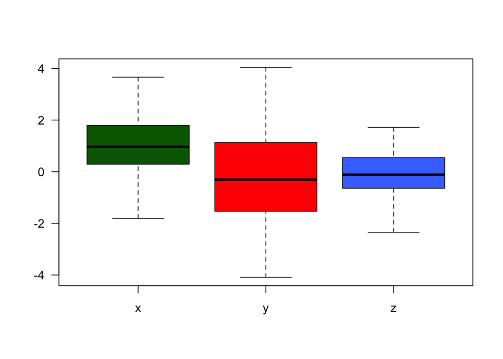

```r
# Define some iid data
x = rnorm(100, 1, 1); class(x) = 'green'
y = rnorm(100, 0, 2); class(y) = 'red'
z = rnorm(100, 0, 1)
col_boxplot(list(x=x, y=y, z=z), las=1)
```

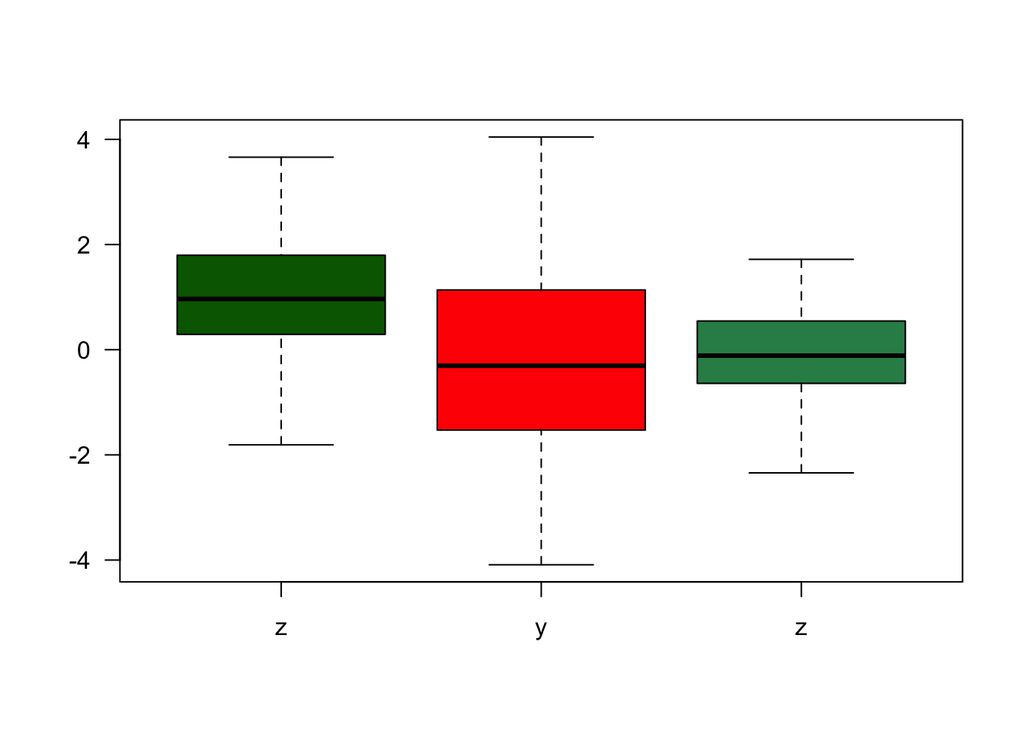

```r
col_boxplot(list(z=x, y=y, z=z), las=1)
```

You should be aware that the class of the object returned by generic functions can depend on the input class.

```r
class(x + y)
```

```
## [1] "green"
```

```r
class(y + x)
```

```
## [1] "red"
```

```r
class(mean(x))
```

```
## [1] "numeric"
```

### Defining an S3 class

The majority of S3 objects are simply lists plus a class attribute. As an example, consider the class `lm` returned by the `lm` function for linear regression modeling,

```r
# How does head.function work?
getS3method('head','function')
```

```
## function (x, n = 6L, ...)
## {
##     lines <- as.matrix(deparse(x))
##     dimnames(lines) <- list(seq_along(lines), "")
##     noquote(head(lines, n = n))
## }
## <bytecode: 0x7f9e28883698>
## <environment: namespace:utils>
```

```r
# Borrow the structure to read lm line by line
lines = deparse(lm)

# Print lines involving 'list' keyword
noquote(lines[grep('list', lines)])
```

```
## [1]         z <- list(coefficients = if (is.matrix(y)) matrix(, 0,
```

```r
# Print lines involving 'class' keyword
noquote(lines[grep('class', lines)])
```

```
## [1]     class(z) <- c(if (is.matrix(y)) "mlm", "lm")
```

## The S4 System

The S3 system described above is very flexible making it easy to work with, but at the expense of the safety and uniformity of a more formal OO system.

The S4 system is a more formal OO system in R. One key difference is that S4 classes have formal definitions and classes, methods, and generics must all be explicitly defined as such.

### Defining an S4 class

S4 classes are defined using the `setClass` function:

```r
setClass("color_vector",
   representation(
     name='character',
     data='numeric',
     color='character'
   )
)
```

Create a new instance of an S4 class using `new`:

```r
x = new("color_vector", name="x", color="darkgreen")
x
```

```
## An object of class "color_vector"
## Slot "name":
## [1] "x"
##
## Slot "data":
## numeric(0)
##
## Slot "color":
## [1] "darkgreen"
```

The function `new` is used above as a *constructor* for creating an object with the desired class. Most S4 classes defined in packages you download have their own constructors which you should use when defined. We can create a constructor by assigning the output of `setClass` a name:

```r
color_vector =
 setClass("color_vector",
   representation(
     name='character',
     data='numeric',
     color='character'
   )
 )
y = color_vector(name="y", data = rnorm(100, 0, 2), color="red")
class(y)
```

```
## [1] "color_vector"
## attr(,"package")
## [1] ".GlobalEnv"
```

### Accessing slots in an S4 object

You can access and set attributes for an S4 object using an `@` symbol, the `slot` function, or an `attr(obj, 'name')` construction:

```r
## Access slots using @
x@color
```

```
## [1] "darkgreen"
```

```r
# Assign some data to the data slot
x@data = rnorm(10, 1, 1)

# Check the color
slot(x, 'color')
```

```
## [1] "darkgreen"
```

```r
# Change the name of x
attr(x, 'name') = 'Green Values'
names(attributes(x))
```

```
## [1] "name"  "data"  "color" "class"
```

### S4 Methods

We can control how an object of class `color_vector` gets printed by defining a `show` method (the S4 equivalent of `print`).

```r
## This is an S4 generic
show(x)
```

```
## An object of class "color_vector"
## Slot "name":
## [1] "Green Values"
##
## Slot "data":
##  [1]  1.59136722  0.33677899  0.94226062  0.67970685 -1.85936006
##  [6]  1.01355773  0.84361872  2.29178598  2.82057760 -0.04796117
##
## Slot "color":
## [1] "darkgreen"
```

```r
## Change how color_vector objects are shown.
setMethod('show', 'color_vector',
  function(object) {
    msg = sprintf('name: %s, color: %s\n\n', object@name, object@color)
    cat(msg)
    cat('Data:')
    str(object@data)
    cat('\n')
  }
)
```

```
## [1] "show"
```

Now, when we call `show` on an object of class `color_vector` R will use the custom method.

```r
slot(x, 'data') = rnorm(100, 1, 1)
show(x)
```

```
## name: Green Values, color: darkgreen
##
## Data: num [1:100] 1.9595 0.3456 0.9051 0.0274 -0.6824 ...
```

## Resources

- “Object Oriented Programming” (chapter 9) in Norman Matloff’s *The Art of R Programming*.
- [“OO Field Guide”](http://adv-r.had.co.nz/OO-essentials.html) (chapter 7) in Hadley Wickham’s *Advanced R*.
- [The R Language](http://dept.stat.lsa.umich.edu/~kshedden/Courses/Stat506/r_language/) from Professor Shedden’s 2016 course notes.
- *Programmer’s Niche: A simple class, in S3 and S4* by Thomas Lumley on page 33 at this [link](https://cran.r-project.org/doc/Rnews/Rnews_2004-1.pdf)
- The [R6 package](https://cran.r-project.org/web/packages/R6/vignettes/Introduction.html) provides `C++` style classes in R.